# Alcohol vs Seat choice

Christina Jones

14 Sept 2021

## Our Goal is to answer this question Is there a difference between the alcohol consumed between the row

## you choose to sit in??

$H_0$ There is no difference in alcohol consumption based on where one sits in class

$H_1$ There is a difference in alcohol consumption based on where one sits in class ## Now with ggplot - first select the basic data

```r
basicCN <- ggplot(davisdata,aes(y=alcohol,x=Seat))
```

## Now add in boxplot

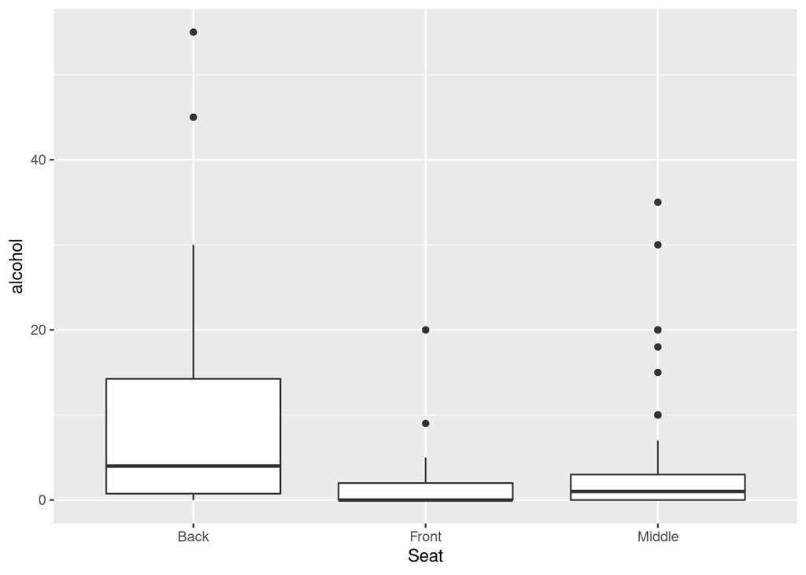

```r
basicCN + geom_boxplot()
```

The box plot shows that people that students that sit in back drink more frequently the students that sit in the front and middle which are seemly the same.

### get fancy

```
## notch went outside hinges. Try setting notch=FALSE.
## notch went outside hinges. Try setting notch=FALSE.
```

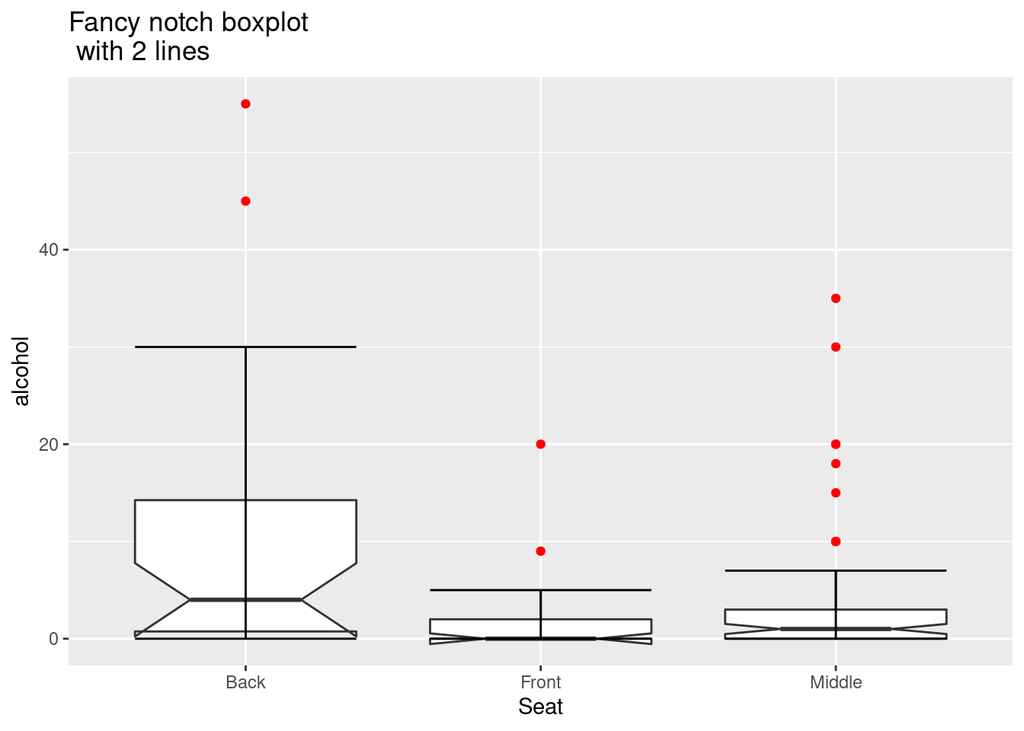

```r
basicCN + geom_boxplot(notch=TRUE,outlier.color = "red") + stat_boxplot(geom ='errorbar') + labs(title="Fancy notch boxplot \n with 2 lines")
```

## Numerical Summarys

```r
favstats(alcohol~Seat,data=ucdavis1)
```

[output not shown]

The table shows that the mean (average) of students that sit in the back row is at 8.555. The students that sit in the front and middle do not exceed 3.33. These averages are very different. The students that sit in the back are much more likely to be alcohol consumers.

## Inferential Tests

```r
model1 <- aov(alcohol~Seat,data=davisdata)
summary.aov(model1)
```

```
##              Df Sum Sq Mean Sq F value   Pr(>F)
## Seat          2   1199   599.4   9.656 0.000116 ***
## Residuals   145   9001    62.1
## ---
## Signif. codes:  0 '***' 0.001 '**' 0.01 '*' 0.05 '.' 0.1 ' ' 1
```

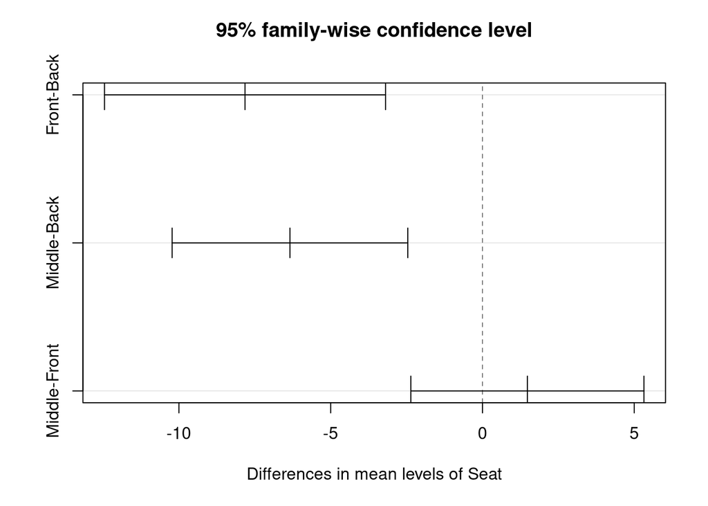

```r
plot(TukeyHSD(model1))
```

We have a p value of 0.000116 so we conclude that we reject the $H_0$;there is a difference with where you sit and the alcohol that is consumed. The tukey test show that the confidence interval contains 0 for Middle-Front. We have no evidence of any difference of alcohol consumption between the students that sit in the middle and the students that sit in the front. There is a significant difference between the confidence level for tukey test. The line does not pass through 0 for the students that front-back.The middle-back line does not pass through the 0 showing a significant as well.

## Conclusions

People that sit in the back drink significantly more then those who sit in the middle or front of the class. We reject the NULL hypothesis because there is a difference in the amount of alcohol consumption with the students that sit in the back row.